# MATH 3070 Lab Project 3

## Problem 3 (Verzani problem 2.32 modified)

*Write a function ‘density_compare()’ that fits a density estimate to a given data set and plots that estimate along with the appropriate histogram of the given data set. Try your function with the data set `pi2000` (**UsingR**). Why might you want to add an argument like `breaks = 0:10-.5` to `hist()`? (Hint: read the documentation of `hist()` to see what setting this argument does). Feel free to add other parameters to your plot methods to see how they can be changed.*

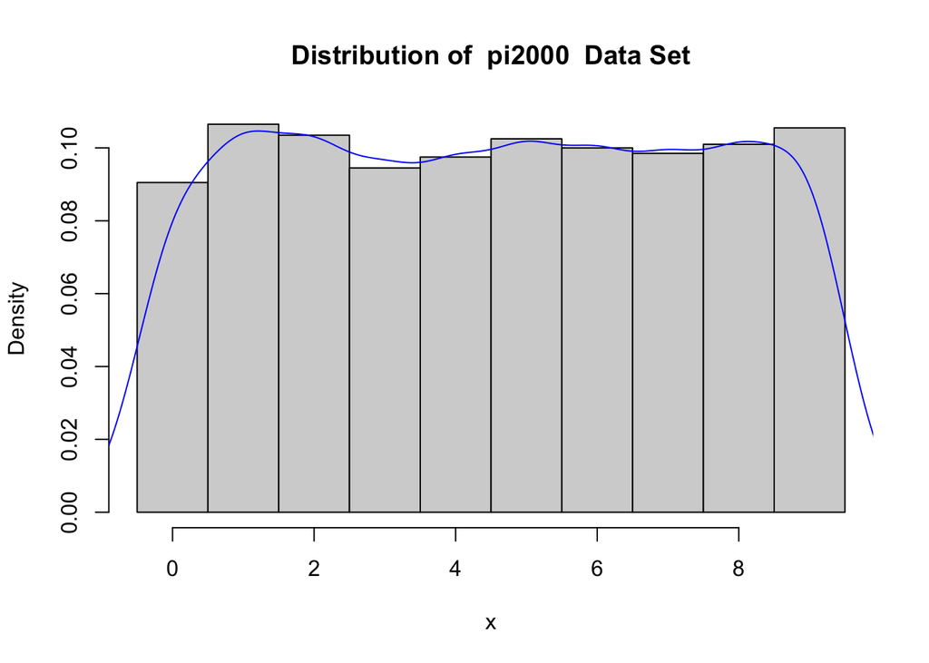

```r
density_compare = function(x){
  hist(x, main=paste("Distribution of ", deparse(substitute(x)), " Data Set"),
       freq=FALSE, breaks=0:10-.5)
  lines(density(x), col="blue")
}

density_compare(pi2000)
```

## BONUS (Verzani problem 2.25)

*Write a function `isprime()` that checks if a number $x$ is prime by dividing $x$ by all the values in $2, ..., x - 1$ then checking to see if there is a remainder of 0. The expression `a %% b` returns the remainder of `a` divided by `b`.*

```r
isprime = function(x){
  results = x%%seq(2, x-1)
  if(0%in%results){
    print("Input is not prime")
  }
  else{
    print("Input is prime")
  }
}

isprime(1703)
```

```
## [1] "Input is not prime"
```

*You do not need to check all numbers from 2 to $x - 1$ to see if a number is prime. What is the largest you would need to go for an arbitrary $x$? Create a new function, `isprime2()`, that implements this better (yet still slow) method.*

```r
isprime2 = function(x){
  results = x%%seq(2, sqrt(x)) #going past sqrt(x) will just result in checking already-checked factor pairs
  if(0%in%results){
    print("Input is not prime")
  }
  else{
    print("Input is prime")
  }
}

isprime(17)
```

```
## [1] "Input is prime"
```